# An Investigation into Numerical Solutions for the Korteweg-de Vries (KdV) Equation

The KdV equation is an important nonlinear PDE that has many applications and variations used to describe physical systems. The equation primarily takes the form

$$\frac{\partial u}{\partial t} + \frac{\partial^3 u}{\partial x^3} + u\frac{\partial u}{\partial x} = 0, \qquad (\dagger)$$
which is the KdV equation’s simplified, nondimensional form that can be used to describe wave shapes in shallow waters. One of the interesting properties of the KdV equation is that its solutions take the form of *Soliton waves*, solitary waves that propagate at a constant velocity and retain their waveform and velocity after colliding with other soliton waves. Their name is a conglomeration of two of the waves’ properties - “solit-” as these waves travel alone, “-on” to associate these waves with particles e.g. bosons, fermions etc.

It is worth noting that the KdV equation is a classical example of an **integrable system**. This means that the equation exhibits regular motion as opposed to random, chaotic motion apparent in other physical systems - in other words, exact solutions can be obtained from the KdV equation through analytical means. **GWD: This is not a good characterisation of integrable equations. Also non-integrable equations can have non-chaotic solutions and some of them can be determined analytically.** The simplest known solution to the equation describes a singular soliton wave propagating with a constant velocity $c$ starting at the point $x=0$ and travelling towards positive $x$ space. Such a wave is described by the following equation:

$$u(x,t) = \frac{c}{2} \frac{1}{\cosh^2{\frac{\sqrt{c}}{2}(x-ct)}}. \qquad(\ddagger)$$
To begin looking for numerical solutions to the KdV equation we must first construct a finite difference scheme for $(\dagger)$. Applying the forward difference scheme to the time derivative term, we can easily find

$$\frac{\partial{u}}{\partial{t}}(x_k,t_j) = \frac{u(x_k,t_{j+1})-u(x_k,t_j)}{\tau} + \mathcal{O}(\tau) = \frac{w_{k,j+1}-w_{k,j}}{\tau},$$
**GWD: The second equality above is not correct. The $w_{k,j}$ are only approximations to $u(x_k,t_j)$ and the difference quotient is not equal to the derivative of $u$. The same applies to the next equation.** where $x_{k} = kh$, $t_{j} = j\tau$ are the $k$-th, $j$-th space and time steps respectively after discretizing the equation and $w_{kj}$ is the numerical approximation to $u(x_k,t_j)$. Now we apply the central difference scheme to the space steps:

$$u(x_k,t_j)\frac{\partial u}{\partial x}(x_k,t_j) = u(x_k,t_j)\Big(\frac{u(x_{k+1},t_j)-u(x_{k-1},t_j)}{2h}\Big) + \mathcal{O}(h^2) = \frac{w_{k,j}(w_{k+1,j}-w_{k-1,j})}{2h}.$$

To calculate the finite difference for the third order derivative consider the following:

$$\frac{\partial^3 u}{\partial x^3}(x_k,t_j) = \frac{\partial f}{\partial x}(x_k,t_j), \qquad f(x_k,t_j) = \frac{u(x_{k+1},t_j)-2u(x_k,t_j) + u(x_{k-1},t_j)}{h^2} + \mathcal{O}(h^2)$$

Once again applying the central difference scheme, we find:

$$\frac{\partial f}{\partial x}(x_k,t_j) = \frac{f(x_{k+1},t_j)-f(x_{k-1},t_j)}{2h} + \mathcal{O}(h^2) = \frac{u(x_{k+2},t_j) - 2u(x_{k+1},t_j) + 2u(x_{k-1},t_j) - u(x_{k-2},t_j))}{2h^3} + \mathcal{O}(h^3).$$
**GWD: the error is still $O(h^2)$.**

Now substituting back into $(\dagger)$:

$$\frac{w_{k,j+1}-w_{k,j}}{\tau} + \frac{w_{k,j}(w_{k+1,j}-w_{k-1,j})}{2h} + \frac{w_{k+2,j}-2w_{k+1,j}+2w_{k-1,j}-w_{k-2,j}}{2h^3} = 0,$$
which has error$\mathcal{O}(\tau + h^2)$. Rearraging for $w_{k,j+1}$,

$$w_{k,j+1} = w_{k,j}\Big(1-\frac{\tau}{2h}(w_{k+1,j}-w_{k-1,j})\Big) + w_{k+1,j}\Big(\frac{\tau}{h^3}\Big) - w_{k-1,j}\Big(\frac{\tau}{h^3}\Big) - w_{k+2,j}\Big(\frac{\tau}{2h^3}\Big) + w_{k-2,j}\Big(\frac{\tau}{2h^3}\Big).$$
This equation can be condensed by building an (N+1)x(N+1) matrix

$$A = \begin{bmatrix}
a_1 & b_1 & c_1 & 0 & \dots & \dots & \dots & \dots & 0 \\
-b_2 & a_2 & b_2 & c_2 & 0 & \dots & \dots & \dots& \vdots \\
-c_3 & -b_3 & a_3 & b_3 & c_3 & 0 & \dots & \dots & \vdots \\
0 & -c_4 & -b_4 & a_4 & b_4 & c_4 & 0 & \dots & \vdots \\
\vdots & \ddots & \ddots & \ddots & \ddots & \ddots & \ddots & \ddots & b_N \\
0 & \dots & \dots & \dots & &0 & -c_{N+1} & -b_{N+1} & a_{N+1}
\end{bmatrix}$$

where $a_k = \Big(1-\frac{\tau}{2h}(w_{k+1,j}-w_{k-1,j})\Big)$, $b_k = \Big(\frac{\tau}{h^3}\Big)$ and $c_k = -\Big(\frac{\tau}{2h^3}\Big)$.

**GWD: It seems that you did not notice that this matrix depends on $w$ at time step $j$ and thus changes at every time step. Your code below uses the matrix as it is at the initial time. This is the reason you get wrong results. Please re-read the section on the non-linear heat equation.**

By the definition of the KdV equation we also have that $u(x,t)$ tends to zero for $x=\pm \infty$ so we set boundary conditions $u(x,0)=u(x,L)=0$. Taking equation $(\ddagger)$ at $t=0$ and letting $c=4$, we have the inital vector required to set up the finite difference problem. Begin by setting up the parameters for space, time and the initial equation:

```r
sech<-function(x){1/cosh(x)} #defining sech function for R
h <- 0.1 #setting up space grid
N <- 100
x <- (0:N)*h
tau <- 0.00001 #setting up time grid
M <- 100000
M1 <- 100  # Save the solution only at 100 time steps
M2 <- M/M1
t <- (0:M1)*M2*tau
u0 <- c(2*sech(x-5)^2) #setting the initial equation
u <- u0
```

Now setting up the matrix $A$:

```r
for(k in 2:(N-1)){
  A<-diag(1-(tau/2*h)*(u[k+1]-u[k-1]),N+1)
  A[k,k+1] <- (tau/h^3)
  A[k+1,k] <- -(tau/h^3)
  A[k,k+2] <- -(tau/2*h^3)
  A[k+2,k] <- (tau/2*h^3)
}
```

**GWD: Your code resets the matrix `A` to a diagonal matrix at every iteration of the loop. Take a look at the result of your code to convince yourself that that is not what you wanted.**

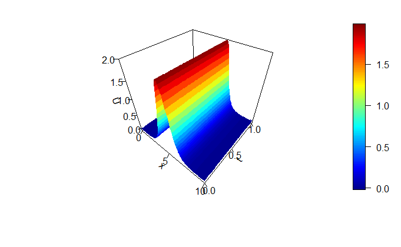

```r
library(plot3Drgl)
persp3D(x, t, U,
        xlab="x", ylab="t", zlab="U", # Provides axis labels
        ticktype="detailed", nticks=4) # Provides axis ticks
```

The first instance of an attempt to obtain numerical solutions to the KdV equation was done by Zabusky and Kruskal in 1965. They developed the finite difference method:

$$w_{k,j+1} = w_{k,j-1} -\frac{\tau}{3h}(w_{k+1,j} + w_{k,j} + w_{k-1,j})(w_{k+1,j} - w_{k-1,j}) - \frac{\tau}{h^3}(w_{k+2,j} - 2w_{k+1,j} + 2w_{k-1,j} - w_{k-2,j}),$$
which again can be written in matrix form,

$$\mathbf{w}^{(j+1)} = \mathbf{w}^{(j-1)} + B\mathbf{w}^j.$$
Matrix $B$ is defined

$$B = \begin{bmatrix}
d_1 & e_1 & f_1 & 0 & \dots & \dots & \dots & \dots & 0 \\
i_2 & d_2 & e_2 & f_2 & 0 & \dots & \dots & \dots& \vdots \\
h_3 & i_3 & d_3 & e_3 & f_3 & 0 & \dots & \dots & \vdots \\
0 & h_4 & i_4 & d_4 & e_4 & f_4 & 0 & \dots & \vdots \\
\vdots & \ddots & \ddots & \ddots & \ddots & \ddots & \ddots & \ddots & e_N \\
0 & \dots & \dots & \dots & &0 & h_{N+1} & i_{N+1} & d_{N+1}
\end{bmatrix},$$

```r
sech<-function(x){1/cosh(x)}
h <- 0.1
N <- 50
x <- (0:N)*h
tau <- 0.001
M <- 50
t <- (0:M)*tau
u0 <- c(0.5*sech(0.5*x)^2)
u <- u0
```

and similarly set up the new quintdiagonal matrix

```r
for(k in 2:(N-1)) {
  A<-diag(-(1/3)*(tau/h)*(u[k+1]-u[k-1]),N+1)
  A[k,k+1] <- -(1/3)*(tau/h)*(u[k+1]-u[k-1])-2*(tau/h^3)
  A[k+1,k] <- -(1/3)*(tau/h)*(u[k+1]-u[k-1])+2*(tau/h^3)
  A[k,k+2] <- (tau/h^3)
  A[k+2,k] <- -(tau/h^3)
}
```

However there are two timesteps involved in the equation now. Therefore we must define two separate vectors to conduct the finite difference method:

```r
u1 <- u
u2<- A%*%u
U <- matrix(0, N+1, M+1) # Matrix to hold the solution
U[ , 1] <- u
for (j in 0:M-1) {
  u2<- A%*%u2 + u1
  u1<-u2
  U[ , j+2] <- u2
}
```

**GWD: Your code assigned to an undefined array called ‘Temperature’. The code gave you the error messaget that ‘Temperature’ was not found. I am surprised that that error message did not enable you to find and fix the error. I have fixed it above..** and plotting the solutions

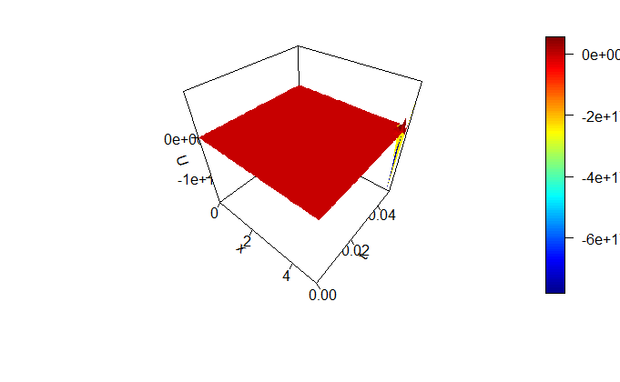

```r
persp3D(x, t, U,
        xlab="x", ylab="t", zlab="U", # Provides axis labels
        ticktype="detailed", nticks=4) # Provides axis ticks
```

[figure not shown]

```r
plot(x, U[,1],type="l", xlab="x", ylab="U")
```

```r
lines(x, U[,10000], col="red")#line for u(x,0.2)
```

```
Error in U[, 10000] : subscript out of bounds
```

## References

[1] N. J. Zabusky and M. D. Kruskal (1965). INTERACTION OF “SOLITONS” IN A COLLISIONLESS PLASMA AND THE RECURRENCE OF INITIAL STATES. Available: http://journals.aps.org/prl/pdf/10.1103/PhysRevLett.15.240. Last accessed 22nd Mar 2017

[2] Maciej Dunajski (2012). INTEGRABLE SYSTEMS. Available: http://www.damtp.cam.ac.uk/user/md327/ISlecture_notes_2012.pdf. Last accessed 22nd Mar 2017